# Analyzing and Visualizing Ridership Patterns in Île-de-France Rail Network

Author

MOURA Pedro, DUCHINSKI Marcos, AGUIRRE Max

Published

January 8, 2026

# Summary

This report presents a comprehensive analysis of ridership patterns across the Île-de-France railway network from 2018 to 2024. Our analysis reveals significant variations in ridership patterns influenced by seasonal factors, holidays, and the COVID-19 pandemic. We have developed an interactive Shiny dashboard to monitor ridership against a standard “normal” week and identify seasonal patterns.

**Key Findings:**

# 1. Data Collection and Cleaning

## 1.1 Data Sources

We used the data available on île de france mobilité.

## 1.2 Data Loading and Initial Processing

The cleaning process involves several critical steps to ensure data quality and consistency:

```r
# Load cleaned validation data
validations <- read_parquet("validations.parquet")

# Load station geographic data
zd <- st_read("zd.shp", quiet = TRUE)

# Display data structure
cat("Dataset dimensions:", nrow(validations), "rows ×", ncol(validations), "columns\n")
```

```
Dataset dimensions: 12549567 rows × 6 columns
```

```r
cat("Date range:", as.character(min(validations$JOUR)), "to", as.character(max(validations$JOUR)), "\n")
```

```
Date range: 2018-01-01 to 2024-06-30
```

```r
cat("Number of unique stations:", n_distinct(validations$ID_REFA_LDA), "\n")
```

```
Number of unique stations: 741
```

### Data Cleaning Steps

The complete cleaning process (see `cleaning.R`) includes:

1. **Consolidating multiple data files**: Merging multiple separate semester files from 2018-2024
2. **Standardizing column names**: Harmonizing different naming conventions across years
3. **Date parsing**: Converting multiple date formats to a unified `Date` type
4. **Removing incomplete records**: Filtering out rows with missing critical values
5. **Standardizing ticket categories**: Unifying ticket type labels (e.g., “Imagine R” → “IMAGINE R”)
6. **Geographic matching**: Ensuring all validation records correspond to valid station locations
7. **Aggregating data**: Grouping by station, date, and ticket category
8. **Additional shiny processing**: Additional pre-processing before deploying the application to remove as much load as possible on the memory

```r
# Summary of ticket categories after standardization
ticket_summary <- validations %>%
  group_by(CATEGORIE_TITRE) %>%
  summarise(
    `Total Validations` = sum(NB_VALD, na.rm = TRUE),
    `% of Total` = round(sum(NB_VALD, na.rm = TRUE) / sum(validations$NB_VALD) * 100, 2)
  ) %>%
  arrange(desc(`Total Validations`))

kable(ticket_summary,
      caption = "Distribution of Validations by Ticket Category",
      format.args = list(big.mark = ",")) %>%
  kable_styling(bootstrap_options = c("striped", "hover", "condensed"))
```

Distribution of Validations by Ticket Category

| CATEGORIE_TITRE | Total Validations | % of Total |
| --- | --- | --- |
| NAVIGO | 5,011,856,805 | 51.81 |
| IMAGINE R | 1,782,688,429 | 18.43 |
| FGT | 1,189,081,435 | 12.29 |
| TST | 736,648,849 | 7.61 |
| NON DEFINI | 376,685,839 | 3.89 |
| AUTRE TITRE | 351,454,820 | 3.63 |
| AMETHYSTE | 225,649,695 | 2.33 |

## 1.3 Holiday Definition

To properly identify patterns, we define French public holidays:

```r
# Define French public holidays
holidays <- as.Date(c(
    "2025-01-01", # Jour de l'An
    "2025-04-21", # Lundi de Pâques
    "2025-05-01", # Fête du Travail
    "2025-05-08", # Armistice
    "2025-05-29", # Ascension
    "2025-06-09", # Lundi de Pentecôte
    "2025-07-14", # Fête Nationale
    "2025-08-15", # Assomption
    "2025-11-01", # Toussaint
    "2025-11-11", # Armistice
    "2025-12-25" # Noël
))
holidays_md <- format(holidays, "%m-%d")

# Add holiday indicator to validation data
validations <- validations %>%
  mutate(
    JOUR = as.Date(JOUR),
    day_of_week = weekdays(JOUR),
    is_holiday = ifelse(JOUR %in% holidays, "Holiday", "Normal Day")
  )
```

# 2. Exploratory Data Analysis

## 2.1 Overall Ridership Statistics

```r
# Calculate key statistics
total_ridership <- sum(validations$NB_VALD, na.rm = TRUE)
total_stations <- n_distinct(validations$ID_REFA_LDA)
total_days <- n_distinct(validations$JOUR)
global_daily_avg <- total_ridership / total_days

# Create summary table
summary_stats <- data.frame(
  Metric = c("Total Ridership", "Active Stations", "Days Recorded", "Average Daily Ridership", "Date Range"),
  Value = c(
    format(total_ridership, big.mark = ","),
    format(total_stations, big.mark = ","),
    format(total_days, big.mark = ","),
    format(round(global_daily_avg), big.mark = ","),
    paste(min(validations$JOUR), "to", max(validations$JOUR))
  )
)

kable(summary_stats,
      caption = "Network-Wide Ridership Statistics",
      col.names = c("Metric", "Value")) %>%
  kable_styling(bootstrap_options = c("striped", "hover"), full_width = FALSE)
```

Network-Wide Ridership Statistics

| Metric | Value |
| --- | --- |
| Total Ridership | 9,674,065,872 |
| Active Stations | 741 |
| Days Recorded | 2,373 |
| Average Daily Ridership | 4,076,724 |
| Date Range | 2018-01-01 to 2024-06-30 |

## 2.2 Holiday vs. Normal Day Analysis

Ridership patterns differ significantly between holidays and normal days:

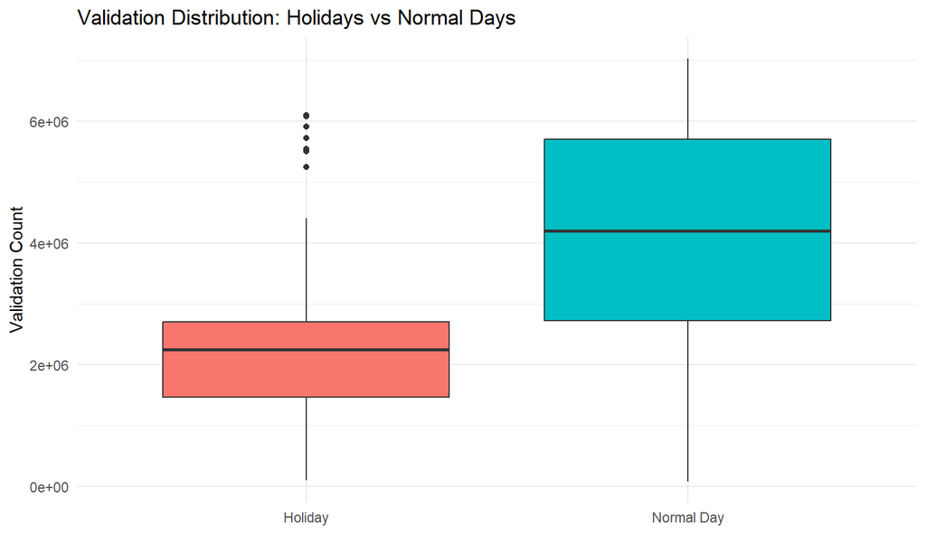

Distribution of daily validations: holidays vs. normal days

```r
validations = read_parquet("validations.parquet")

tot_val_per_day <- validations |>
  group_by(JOUR) |>
  summarise(NB_VALD=sum(NB_VALD), is_holiday=first(is_holiday))

avg_vals <- tot_val_per_day %>%
  group_by(is_holiday) %>%
  summarise(mean_val = mean(NB_VALD, na.rm = TRUE))


ggplot(tot_val_per_day, aes(x = is_holiday, y = NB_VALD, fill = is_holiday)) +
  geom_boxplot(show.legend = FALSE) +
  labs(
    title = "Validation Distribution: Holidays vs Normal Days",
    x = "",
    y = "Validation Count"
  ) +
  theme_minimal()
```

## 2.3 Weekday Patterns

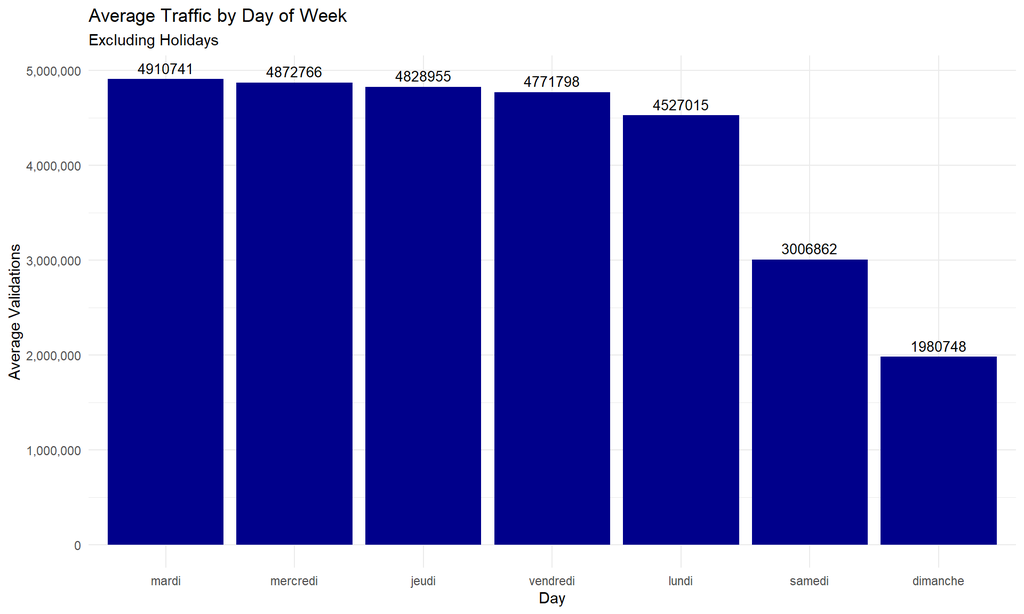

Average ridership by day of week (excluding holidays)

```r
weekday_stats <- validations %>%
  filter(is_holiday == "Normal Day") %>%
  # sum per day first
  group_by(JOUR, day_of_week) %>%
  summarise(daily_total = sum(NB_VALD, na.rm = TRUE), .groups = "drop") %>%
  # then average across weekdays
  group_by(day_of_week) %>%
  summarise(
    avg_daily_val = mean(daily_total, na.rm = TRUE),
    total_val = sum(daily_total, na.rm = TRUE),
    .groups = "drop"
  ) %>%
  arrange(desc(avg_daily_val))

ggplot(weekday_stats, aes(x = reorder(day_of_week, -avg_daily_val), y = avg_daily_val)) +
    geom_col(fill = "darkblue") +
    geom_text(aes(label = round(avg_daily_val, 0)), vjust = -0.5, size = 3.5) +
    scale_y_continuous(labels = scales::comma) +
    labs(
        title = "Average Traffic by Day of Week",
        subtitle = "Excluding Holidays",
        x = "Day",
        y = "Average Validations"
    ) +
    theme_minimal()
```

**Key Observations**:

- Weekdays (Monday-Friday) show consistently high ridership
- Weekend ridership (Saturday-Sunday) is significantly lower, reflecting reduced commuter activity

## 2.4 Ridership by Transport Mode

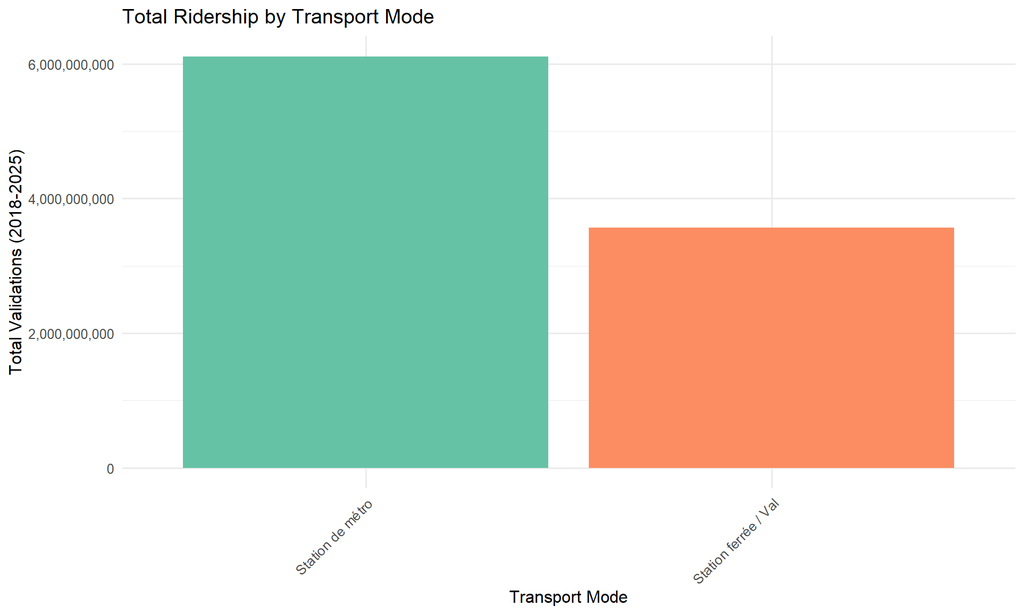

Total validations by transport mode

```r
# Prepare station type data
zd_clean <- zd %>%
  mutate(
    idrefa_lda = as.character(idrefa_lda),
    idrefa_lda = sub("\\.0$", "", idrefa_lda)
  )

zd_lookup <- zd_clean %>%
  st_drop_geometry() %>%
  select(idrefa_lda, type_arret) %>%
  distinct(idrefa_lda, .keep_all = TRUE)

# Join with validations
val_joined <- validations %>%
  left_join(zd_lookup, by = c("ID_REFA_LDA" = "idrefa_lda"))

# Aggregate by mode
mode_summary <- val_joined %>%
  filter(!is.na(type_arret)) %>%
  group_by(type_arret) %>%
  summarise(total_val = sum(NB_VALD, na.rm = TRUE), .groups = "drop") %>%
  arrange(desc(total_val))

# Plot
ggplot(mode_summary, aes(x = reorder(type_arret, -total_val), y = total_val, fill = type_arret)) +
  geom_col(show.legend = FALSE) +
  scale_y_continuous(labels = comma) +
  scale_fill_brewer(palette = "Set2") +
  labs(
    title = "Total Ridership by Transport Mode",
    x = "Transport Mode",
    y = "Total Validations (2018-2025)"
  ) +
  theme_minimal(base_size = 12) +
  theme(axis.text.x = element_text(angle = 45, hjust = 1))
```

## 2.5 Ticket Category Analysis

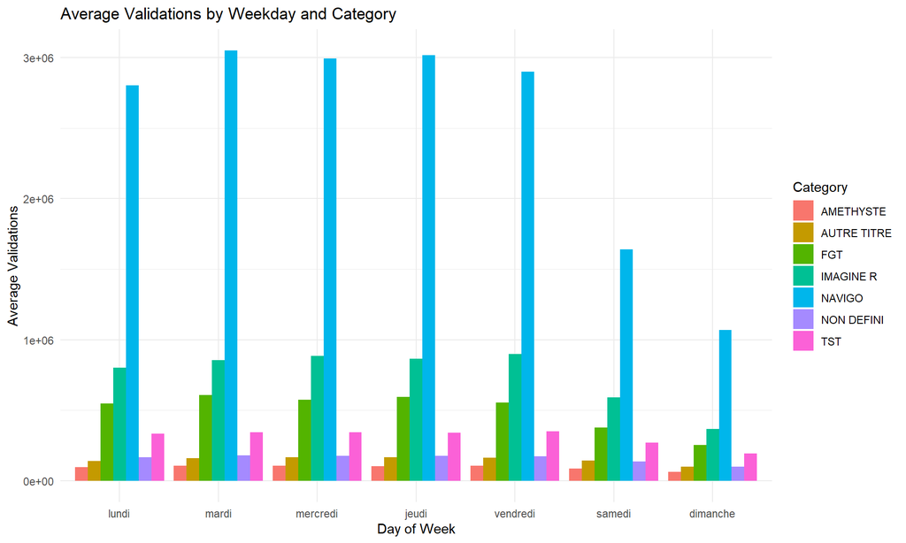

Average validations by weekday and ticket category

```r
validations = read_parquet("validations.parquet")
daily_totals <- validations %>%
  group_by(JOUR, day_of_week, CATEGORIE_TITRE) %>%
  summarise(total_val = sum(NB_VALD, na.rm = TRUE), .groups = "drop")

val_summary <- daily_totals %>%
  group_by(day_of_week, CATEGORIE_TITRE) %>%
  summarise(mean_val = mean(total_val, na.rm = TRUE), .groups = "drop")

ggplot(val_summary, aes(x = day_of_week, y = mean_val, fill = CATEGORIE_TITRE)) +
  geom_col(position = "dodge") +
  labs(
    title = "Average Validations by Weekday and Category",
    x = "Day of Week",
    y = "Average Validations",
    fill = "Category"
  ) +
  theme_minimal()
```

# 3. Temporal Analysis

## 3.1 Weekly Evolution

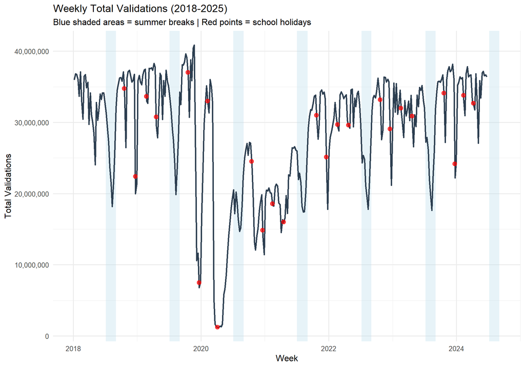

Weekly total validations over time with seasonal highlights

```r
# Calculate weekly totals
weekly_validations <- validations %>%
  group_by(week = floor_date(JOUR, unit = "week")) %>%
  summarise(total_validations = sum(NB_VALD, na.rm = TRUE), .groups = "drop") %>%
  filter(week != min(week) & week != max(week))  # Remove incomplete weeks

# Define summer breaks (Zone C)
summer_breaks <- data.frame(
  start = as.Date(c("2018-07-06", "2019-07-06", "2020-07-04", "2021-07-03",
                    "2022-07-07", "2023-07-08", "2024-07-06")),
  end   = as.Date(c("2018-09-02", "2019-09-02", "2020-09-01", "2021-09-02",
                    "2022-09-01", "2023-09-04", "2024-09-02"))
)

# Define holiday weeks
holiday_dates <- as.Date(c(
  "2018-10-20","2019-10-19","2020-10-17","2021-10-23","2022-10-22","2023-10-21",  # Toussaint
  "2018-12-22","2019-12-21","2020-12-19","2021-12-18","2022-12-17","2023-12-23",  # Christmas
  "2019-02-23","2020-02-08","2021-02-13","2022-02-19","2023-02-18","2024-02-10",  # Winter
  "2019-04-20","2020-04-04","2021-04-17","2022-04-23","2023-04-22","2024-04-06"   # Spring
))

# Interpolate for holiday points
all_dates <- data.frame(date = seq(min(weekly_validations$week),
                                    max(weekly_validations$week), by = "day"))
all_dates <- all_dates %>%
  left_join(weekly_validations %>% rename(date = week), by = "date") %>%
  arrange(date) %>%
  mutate(total_validations = zoo::na.approx(total_validations, na.rm = FALSE))

holiday_points <- all_dates %>%
  filter(date %in% holiday_dates)

# Plot
ggplot(weekly_validations, aes(x = week, y = total_validations)) +
  geom_rect(data = summer_breaks,
            inherit.aes = FALSE,
            aes(xmin = start, xmax = end, ymin = -Inf, ymax = Inf),
            fill = "lightblue", alpha = 0.3) +
  geom_line(color = "#2C3E50", linewidth = 0.9) +
  geom_point(data = holiday_points,
             aes(x = date, y = total_validations),
             color = "red", size = 2.5, alpha = 0.7) +
  scale_y_continuous(labels = comma) +
  labs(
    title = "Weekly Total Validations (2018-2025)",
    subtitle = "Blue shaded areas = summer breaks | Red points = school holidays",
    x = "Week",
    y = "Total Validations"
  ) +
  theme_minimal(base_size = 12)
```

**Key Observations**:

- Clear annual cyclical pattern with dips during summer breaks
- Dramatic decline during COVID-19 lockdowns (March 2020 - mid-2021)
- Gradual recovery starting in mid-2021
- Holiday periods consistently show reduced ridership
- Return to near pre-pandemic levels by 2023

## 3.2 Monthly Trends and COVID-19 Impact

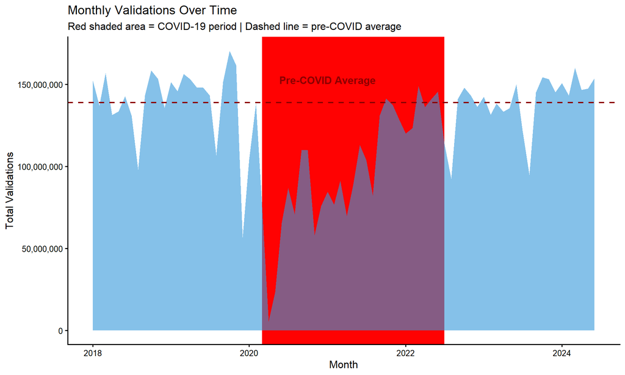

Monthly validations showing COVID-19 impact

```r
# Calculate monthly totals
df_month <- validations %>%
  mutate(
    date = as.Date(JOUR),
    year_month = floor_date(date, unit = "month")
  ) %>%
  group_by(year_month) %>%
  summarise(NB_VALD = sum(NB_VALD, na.rm = TRUE), .groups = "drop")

# Calculate mean (excluding COVID period for baseline)
covid_start <- as.Date("2020-03-01")
covid_end   <- as.Date("2022-06-30")

mean_val_pre_covid <- df_month %>%
  filter(year_month < covid_start) %>%
  summarise(mean = mean(NB_VALD)) %>%
  pull(mean)

# Plot
ggplot(df_month, aes(x = year_month, y = NB_VALD)) +
  geom_rect(aes(xmin = covid_start, xmax = covid_end,
                ymin = -Inf, ymax = Inf),
            inherit.aes = FALSE, fill = "red", alpha = 0.2) +
  geom_area(fill = "#3498DB", alpha = 0.6) +
  geom_hline(yintercept = mean_val_pre_covid,
             linetype = "dashed", linewidth = 0.8, color = "darkred") +
  scale_y_continuous(labels = comma) +
  annotate("text", x = as.Date("2021-01-01"), y = mean_val_pre_covid * 1.1,
           label = "Pre-COVID Average", color = "darkred", fontface = "bold") +
  labs(
    title = "Monthly Validations Over Time",
    subtitle = "Red shaded area = COVID-19 period | Dashed line = pre-COVID average",
    x = "Month",
    y = "Total Validations"
  ) +
  theme_classic(base_size = 12)
```

## 3.3 Seasonal Analysis

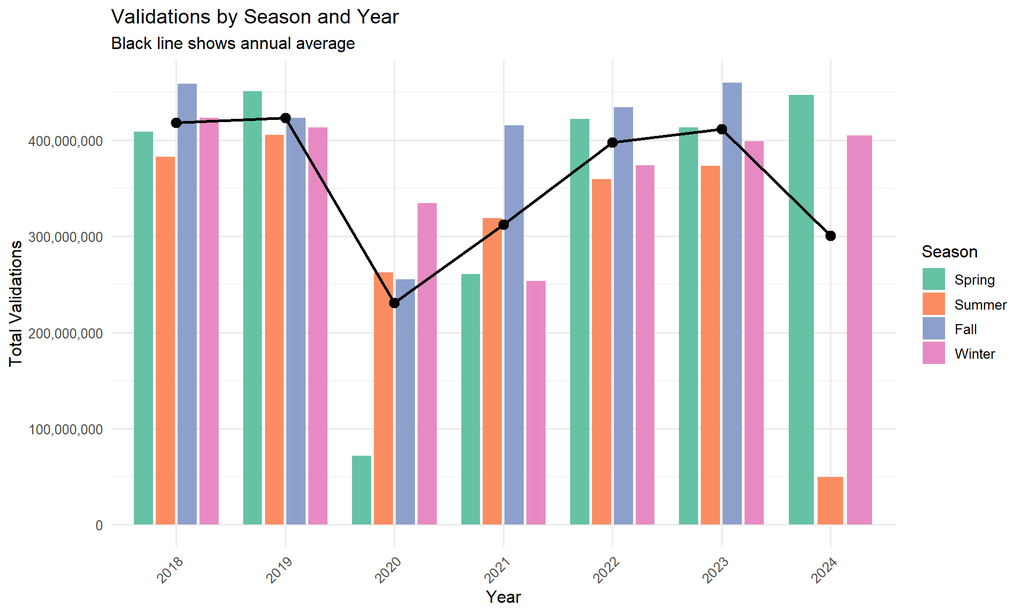

Validations by season and year with annual mean

```r
# Create seasonal aggregation
df_season <- validations %>%
  mutate(
    date = as.Date(JOUR),
    year = year(date),
    md = month(date) * 100 + day(date),
    season = case_when(
      md >= 322 & md < 621 ~ "Spring",   # Mar 22 - Jun 20
      md >= 621 & md < 923 ~ "Summer",   # Jun 21 - Sep 22
      md >= 923 & md < 1222 ~ "Fall",    # Sep 23 - Dec 21
      TRUE ~ "Winter"                     # Dec 22 - Mar 21
    )
  ) %>%
  group_by(year, season) %>%
  summarise(NB_VALD = sum(NB_VALD, na.rm = TRUE), .groups = "drop") %>%
  mutate(season = factor(season, levels = c("Spring", "Summer", "Fall", "Winter")))

# Calculate annual means
df_mean_year <- df_season %>%
  group_by(year) %>%
  summarise(mean_year = mean(NB_VALD, na.rm = TRUE), .groups = "drop")

# Plot
ggplot(df_season, aes(x = factor(year), y = NB_VALD, fill = season)) +
  geom_col(position = position_dodge(width = 0.8), width = 0.7) +
  geom_line(
    data = df_mean_year,
    aes(x = factor(year), y = mean_year, group = 1),
    inherit.aes = FALSE,
    linewidth = 1,
    color = "black"
  ) +
  geom_point(
    data = df_mean_year,
    aes(x = factor(year), y = mean_year),
    inherit.aes = FALSE,
    size = 3,
    color = "black"
  ) +
  scale_y_continuous(labels = comma) +
  scale_fill_brewer(palette = "Set2") +
  labs(
    title = "Validations by Season and Year",
    subtitle = "Black line shows annual average",
    x = "Year",
    y = "Total Validations",
    fill = "Season"
  ) +
  theme_minimal(base_size = 12) +
  theme(axis.text.x = element_text(angle = 45, hjust = 1))
```

# 4. Spatial Analysis

## 4.1 Top 30 Busiest Stations

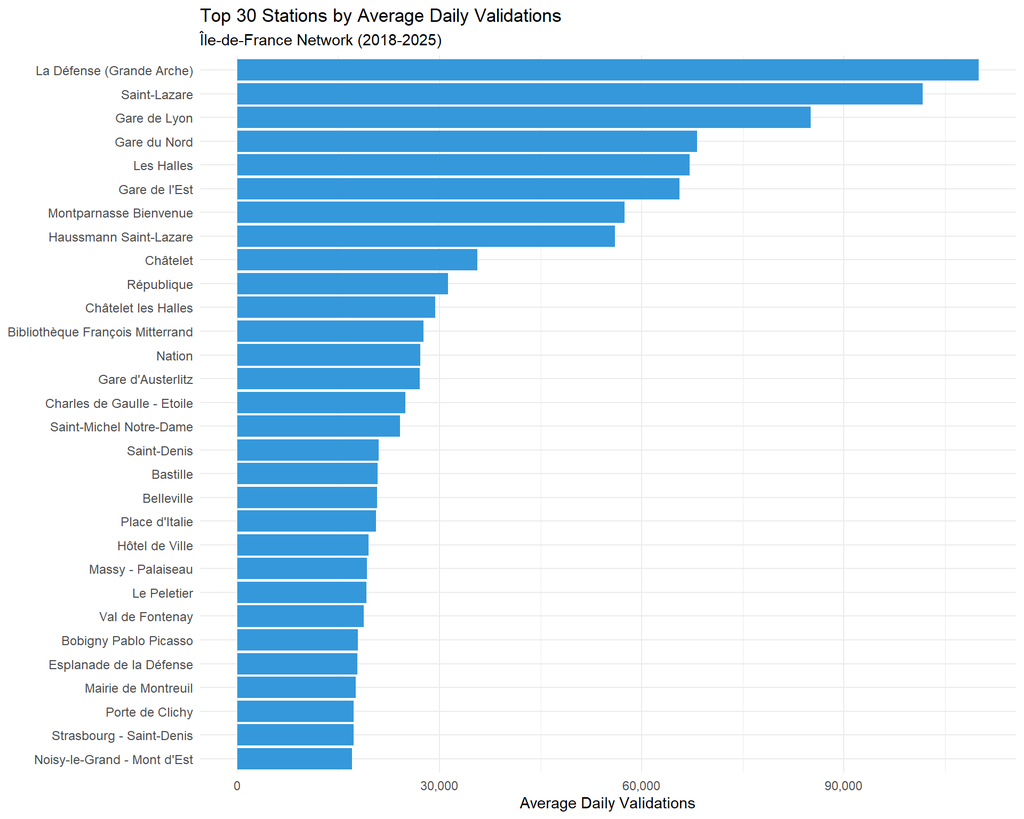

Top 30 stations by average daily validations

```r
# Calculate station averages
station_avg <- validations %>%
  group_by(ID_REFA_LDA, JOUR) %>%
  summarise(daily_val = sum(NB_VALD, na.rm = TRUE), .groups = "drop") %>%
  group_by(ID_REFA_LDA) %>%
  summarise(avg_daily_validations = mean(daily_val, na.rm = TRUE), .groups = "drop")

# Join with station names
zd_names <- zd %>%
  st_drop_geometry() %>%
  select(idrefa_lda, nom_lda = nom) %>%
  distinct(idrefa_lda, .keep_all = TRUE)

station_avg <- station_avg %>%
  left_join(zd_names, by = c("ID_REFA_LDA" = "idrefa_lda")) %>%
  arrange(desc(avg_daily_validations)) %>%
  slice_head(n = 30)

# Plot
ggplot(station_avg, aes(x = reorder(nom_lda, avg_daily_validations),
                        y = avg_daily_validations)) +
  geom_col(fill = "#3498DB") +
  coord_flip() +
  scale_y_continuous(labels = comma) +
  labs(
    title = "Top 30 Stations by Average Daily Validations",
    subtitle = "Île-de-France Network (2018-2025)",
    x = NULL,
    y = "Average Daily Validations"
  ) +
  theme_minimal(base_size = 11) +
  theme(axis.text.y = element_text(size = 9))
```

## 4.2 Geographic Distribution of Ridership

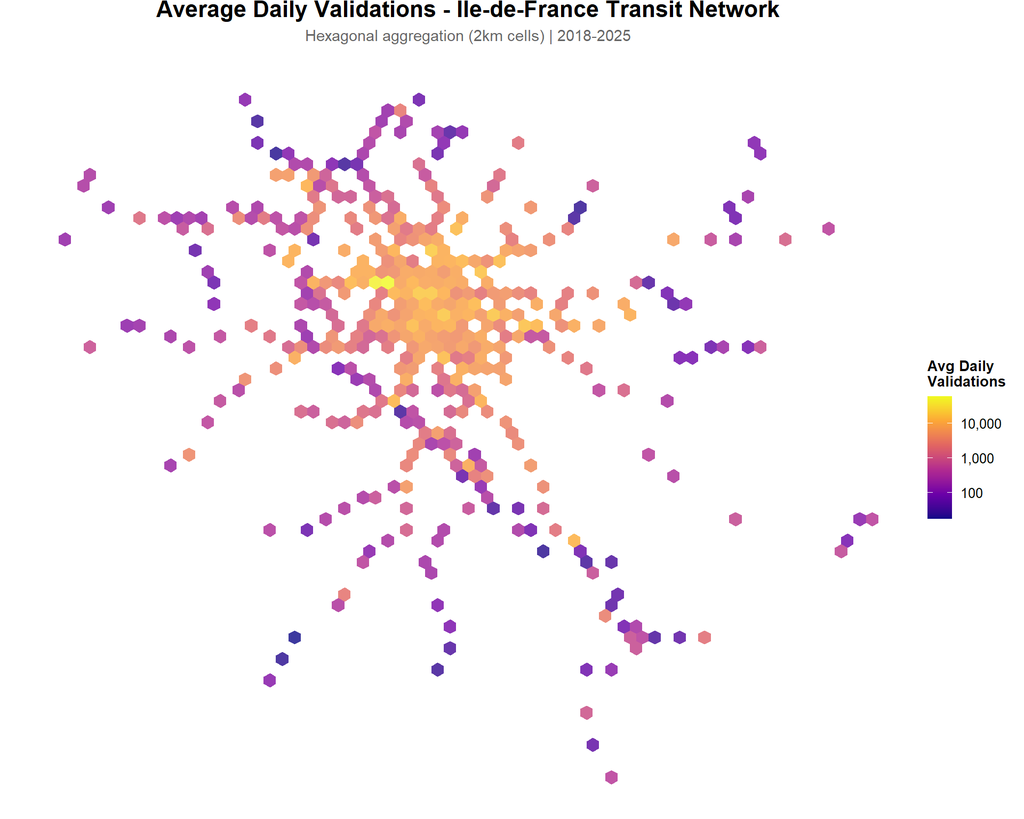

Hexagonal heatmap of average daily validations

```r
# Calculate average validations per station
daily_validations <- validations %>%
  group_by(ID_REFA_LDA, JOUR) %>%
  summarise(daily_val = sum(NB_VALD, na.rm = TRUE), .groups = "drop")

avg_validations_zone <- daily_validations %>%
  group_by(ID_REFA_LDA) %>%
  summarise(avg_validations = mean(daily_val, na.rm = TRUE), .groups = "drop")

# Join with geographic data
zd_with_validation <- left_join(
  zd,
  avg_validations_zone,
  by = c("idrefa_lda" = "ID_REFA_LDA")
)

zd_filtered <- zd_with_validation %>%
  filter(!is.na(avg_validations))

# Create hexagonal grid (2km cells)
hex_grid_geom <- st_make_grid(zd_filtered, cellsize = c(2000, 2000),
                               what = "polygons", square = FALSE)
hex_grid <- st_sf(hex_id = 1:length(hex_grid_geom), geometry = hex_grid_geom)

# Aggregate to hexagonal grid
hex_validation <- st_join(hex_grid, zd_filtered) %>%
  group_by(hex_id) %>%
  summarise(
    avg_validations = mean(avg_validations, na.rm = TRUE),
    n_stations = sum(!is.na(avg_validations)),
    .groups = "drop"
  ) %>%
  filter(n_stations > 0)

# Plot
ggplot() +
  geom_sf(data = hex_validation, aes(fill = avg_validations),
          color = NA, alpha = 0.8) +
  scale_fill_viridis_c(
    option = "plasma",
    name = "Avg Daily\nValidations",
    labels = comma,
    trans = "log10",
    breaks = c(10, 100, 1000, 10000)
  ) +
  labs(
    title = "Average Daily Validations - Île-de-France Transit Network",
    subtitle = "Hexagonal aggregation (2km cells) | 2018-2025"
  ) +
  theme_void(base_size = 12) +
  theme(
    plot.title = element_text(face = "bold", size = 16, hjust = 0.5, margin = margin(b = 5)),
    plot.subtitle = element_text(size = 11, hjust = 0.5, color = "grey40", margin = margin(b = 10)),
    legend.position = "right",
    legend.title = element_text(size = 10, face = "bold"),
    plot.background = element_rect(fill = "white", color = NA)
  )
```

# 5. Definition and Analysis of “The Norm”

## 5.1 Establishing the Baseline

The “norm” represents typical ridership patterns during regular operational conditions. We define it as:

- **Period**: All normal (non-holiday) days
- **Exclusions**:
  - Public holidays
  - COVID-19 period (March 2020 - June 2022)

```r
validations = read_parquet("validations.parquet")
# Define COVID period
covid_start <- as.Date("2020-03-01")
covid_end <- as.Date("2022-06-30")

# Filter for norm calculation
norm_data <- validations %>%
  filter(
    is_holiday == "Normal Day",
    !(JOUR >= covid_start & JOUR <= covid_end)
  )

# Calculate daily network totals
norm_daily_totals <- norm_data %>%
  group_by(JOUR, day_of_week) %>%
  summarise(daily_total = sum(NB_VALD, na.rm = TRUE), .groups = "drop")

# Calculate norm by weekday

norm_by_weekday <- norm_daily_totals %>%
  group_by(day_of_week) %>%
  summarise(
    norm_avg = mean(daily_total, na.rm = TRUE),
    norm_sd  = sd(daily_total, na.rm = TRUE),
    n_days   = n(),
    .groups  = "drop"
  )

# Display table
kable(norm_by_weekday,
      caption = "The Norm: Average Daily Validations by Weekday",
      col.names = c("Weekday", "Average", "Std. Dev.", "Days Sampled"),
      digits = 0,
      format.args = list(big.mark = ",")) %>%
  kable_styling(bootstrap_options = c("striped", "hover"))
```

The Norm: Average Daily Validations by Weekday

| Weekday | Average | Std. Dev. | Days Sampled |
| --- | --- | --- | --- |
| lundi | 5,097,173 | 1,089,487 | 209 |
| mardi | 5,474,851 | 1,104,827 | 210 |
| mercredi | 5,472,041 | 906,840 | 207 |
| jeudi | 5,417,465 | 1,197,402 | 214 |
| vendredi | 5,326,242 | 1,111,272 | 213 |
| samedi | 3,314,340 | 625,722 | 214 |
| dimanche | 2,213,836 | 392,601 | 209 |

## 5.2 Visualizing the Norm

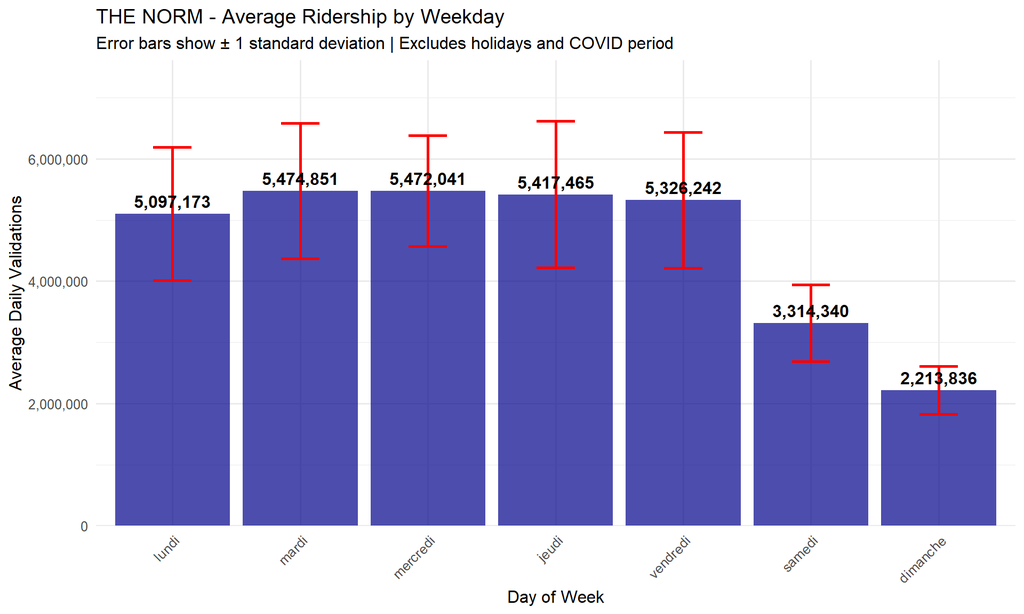

The Norm: Expected ridership by weekday with variability

```r
ggplot(norm_by_weekday, aes(x = day_of_week, y = norm_avg)) +
  geom_col(fill = "darkblue", alpha = 0.7) +
  geom_errorbar(aes(ymin = norm_avg - norm_sd, ymax = norm_avg + norm_sd),
                width = 0.3, color = "red", linewidth = 1) +
  geom_text(aes(label = format(round(norm_avg), big.mark = ","
  )),
            vjust = -0.5, fontface = "bold") +
  scale_y_continuous(labels = comma, expand = expansion(mult = c(0, 0.15))) +
  labs(
    title = "THE NORM - Average Ridership by Weekday",
    subtitle = "Error bars show ± 1 standard deviation | Excludes holidays and COVID period",
    x = "Day of Week",
    y = "Average Daily Validations"
  ) +
  theme_minimal(base_size = 12) +
  theme(axis.text.x = element_text(angle = 45, hjust = 1))
```

# 6. Statistical Methods and Validation

As proposed in the project statement, we have developed an interactive prediction component allowing the forecast of ridership in the network.

To do that, we proposed the following features:

- Linear Model trained on post-covid data to predict the ridership for $N$ user-defined days
- Parametrization for growth adjustment
- Custom Scenarios as:
  - Friday Ridership Drop
  - Special Event with user-defined growth factor and schedule
- Key insights in the impact, as: Daily Average, Peak Volume, Peak Dates, Total Volume, and others.

This model, is available on the section “Advanced Forecast Model” of the dashboard

The linear model, consists on the following structure:

```r
  trained_model <- reactive({
    train_df <- daily_network %>%
      filter(JOUR > as.Date("2022-07-01")) %>%
      mutate(
        time_index = as.numeric(JOUR - min(JOUR)),
        day_num = as.factor(lubridate::wday(JOUR, week_start = 1)),
        month_num = as.factor(lubridate::month(JOUR)),
        is_holiday = as.factor(as.character(is_holiday))
      )
    lm(NB_VALD ~ time_index + day_num + month_num + is_holiday, data = train_df)
  })
```

# 7. Interactive Dashboard Development

## 7.1 Dashboard Architecture

We have developed an interactive Shiny dashboard deployed on shinyapps.io that enables to:

1. **Compare periods against the norm**: Select any time period and visualize deviations from expected ridership
2. **Compare two arbitrary periods**: Analyze differences between reference and comparison periods
3. **Explore individual stations**: Deep dive into station-specific trends and patterns
4. **Monitor overall trends**: Track network-wide evolution over time
5. **Advanced Forecast Model**: Predict and customize Ridership for the next $N$ days

## 7.2 Data Preprocessing for Dashboard

To optimize performance and memory usage, we pre-aggregate the data:

```r
# This code is from preprocessing.R

# 1. Network-wide daily aggregates
daily_network <- validations %>%
  group_by(JOUR, day_of_week, is_holiday) %>%
  summarise(NB_VALD = sum(NB_VALD, na.rm = TRUE), .groups = "drop")

write_parquet(daily_network, "ShinyApp/data/pre_aggregated/daily_network.parquet")

# 2. Station-level daily data
station_daily <- validations %>%
  group_by(JOUR, day_of_week, nom_lda, type_arret, CATEGORIE_TITRE) %>%
  summarise(total_validations = sum(NB_VALD, na.rm = TRUE), .groups = "drop")

write_parquet(station_daily, "ShinyApp/data/pre_aggregated/station_daily.parquet")

# 3. Station metadata
station_metadata <- validations %>%
  group_by(ID_REFA_LDA, nom_lda, type_arret) %>%
  summarise(
    total_validations = sum(NB_VALD, na.rm = TRUE),
    avg_daily = mean(NB_VALD, na.rm = TRUE),
    min_date = min(JOUR),
    max_date = max(JOUR),
    .groups = "drop"
  )

write_parquet(station_metadata, "ShinyApp/data/pre_aggregated/station_metadata.parquet")

# 4. Weekly and mode aggregates
weekly_network <- validations %>%
  mutate(week = floor_date(JOUR, "week")) %>%
  group_by(week) %>%
  summarise(total = sum(NB_VALD, na.rm = TRUE), .groups = "drop")

write_parquet(weekly_network, "ShinyApp/data/pre_aggregated/weekly_network.parquet")
```

## 7.3 Dashboard Access

**Live Dashboard URL**: https://datavizprojectsia.shinyapps.io/RailwayApp/

The dashboard provides five main tabs:

1. **Compare with Norm**: Evaluate recent ridership against historical baseline
2. **Period Comparison**: Compare any two time periods side-by-side
3. **Station Explorer**: Detailed analysis of individual station performance
4. **Overall Trends**: Network-wide evolution and rankings
5. **Advanced Forecast Model**: Linear Model to predict and customize Ridership for the next $N$ days

## 7.4 Dashboard Usage Examples

### Example 1: Identifying Unusual Patterns

Users can select the past 30 days and immediately see whether ridership is above or below expected levels for each weekday, with percentage deviations clearly displayed.

### Example 2: Station Performance Monitoring

Transportation planners can select a specific station and view:

- Weekly ridership trends with smoothed averages
- Average ridership by day of week
- Breakdown by ticket category
- Key statistics (total validations, date range, transport mode)

### Example 3: Recovery Analysis

By comparing Q4 2019 (pre-pandemic) with Q4 2023 (post-recovery), we can quantify the extent of recovery and identify any lasting changes in travel patterns.

### Example 4: Forecast for a major Event

As a stakeholder, this dashboard brings the possibility to predict key insights about the next $N$ days. In the case of a scheduled event, it is possible to predict the impact in the transportation network, based on the predicted growth in a determined date interval range. This, allows the possibility to take conclusions about congestion, and possible preventive measures to be taken.

# 8. Key Findings and Insights

## 8.2 COVID-19 Impact Assessment

```r
daily_network <- validations %>%
  group_by(JOUR, day_of_week, is_holiday) %>%
  summarise(NB_VALD = sum(NB_VALD, na.rm = TRUE), .groups = "drop")

# Pre-COVID average
pre_covid_avg <- daily_network %>%
  filter(JOUR < covid_start) %>%
  summarise(avg = mean(NB_VALD, na.rm = TRUE)) %>%
  pull(avg)

# During COVID (lowest point)
covid_lowest <- daily_network %>%
  filter(JOUR >= covid_start & JOUR <= covid_end) %>%
  summarise(min = min(NB_VALD, na.rm = TRUE)) %>%
  pull(min)

# Recent average (2024)
recent_avg <- daily_network %>%
  filter(year(JOUR) == 2024) %>%
  summarise(avg = mean(NB_VALD, na.rm = TRUE)) %>%
  pull(avg)

# Calculate reductions
max_reduction <- round((1 - covid_lowest / pre_covid_avg) * 100, 1)
current_recovery <- round(recent_avg / pre_covid_avg * 100, 1)

cat("Pre-COVID average daily ridership:", format(round(pre_covid_avg), big.mark = ","), "\n")
```

```
Pre-COVID average daily ridership: 4,567,114
```

```r
cat("Lowest point during COVID:", format(round(covid_lowest), big.mark = ","),
    "(", max_reduction, "% reduction)\n")
```

```
Lowest point during COVID: 76,158 ( 98.3 % reduction)
```

```r
cat("2024 average daily ridership:", format(round(recent_avg), big.mark = ","), "\n")
```

```
2024 average daily ridership: 4,952,107
```

```r
cat("Current recovery rate:", current_recovery, "% of pre-COVID levels\n")
```

```
Current recovery rate: 108.4 % of pre-COVID levels
```

**Major Insights**:

1. Ridership dropped by approximately 98.3% at the pandemic’s peak
2. Recovery has been gradual but steady since mid-2021
3. As of 2024, ridership has recovered to 108.4% of pre-pandemic levels
4. The recovery is not uniform across all stations or transport modes

## 8.3 Seasonal and Temporal Patterns

- **Weekend effect**: Saturday and Sunday show a much lower ridership than weekdays
- **Summer effect**: July-August period shows significant ridership decrease
- **Holiday impact**: Public holidays experience a reduction in ridership
- **School breaks**: Clear dips during vacation periods (February, April, October, December)

# Appendix A: Code Repository

All analysis code is available in the project repository: https://github.com/BoxingBytes/Data_visualization

- `cleaning.R`: Data collection, cleaning, and preprocessing
- `eda.R`: Exploratory data analysis and visualization
- `preprocessing.R`: Pre-aggregation for Shiny dashboard
- `ShinyApp/app.R`: Interactive dashboard code
- `report.qmd`: This Quarto report

## Reproducibility

To reproduce this analysis:

1. Download raw data files from STIF portal
2. Run `cleaning.R` to generate `validations.parquet` and `zd.shp`
3. Run `eda.R` for exploratory visualizations
4. Run `preprocessing.R` to create dashboard data files
5. Render `report.qmd` to generate this report
6. Deploy `ShinyApp/` to shinyapps.io

**Report generated on**: janeiro 08, 2026

**Group members**: MOURA Pedro, DUCHINSKI Marcos, AGUIRRE Max